# Project02 - Group01

Eva, Tobi, Kathi, Laura

24 July 2019

# Table of content

1. Introduction  
1.1 Data loading  
1.2 Data scaling

2. Broad analysis  
2.1 Boxplots  
2.2 Densityplot  
2.3 K-means clustering  
2.4 PCA

# 1. Introduction

Our project is about lapatinib and divided into three parts: Broad analysis, specific analysis and our three main questions. The main questions are the most important part of our project. They address whether cell doubling time correlates with reduced drug sensitivity and the effect of lapatinib on lung cancer and brain metastasis. Twenty-five per cent of breast cancers overexpress ErbB2 / HER which leads to a more aggressive phenotype. Lapatinib blocks tyrosine kinases that belong to the HER2 receptor, which is increasingly found on the cell surface of cancer cells. HER2 is a receptor for the growth factor epidermal growth factor (EGF), which stimulates the cell division of cancer cells. By blocking these HER2 receptors, the unregulated growth of cancer cells can be controlled again. Lapatinib binds the ATP-binding site of the receptor’s intracellular domain and inhibits the survival and proliferation pathways of the tumor cell.

## 1.1 Data loading

## 1.2 Data scaling

After checking for normalization, we scaled our data in the first place to provide the scaled data for further analysis.

```r
list = list(Treated,Untreated)
nlist = lapply(list,scale)
Treated = as.data.frame(nlist[[1]])
Untreated = as.data.frame(nlist[[2]])
Fold_Change = Treated - Untreated
Fold_Change = data.frame(Fold_Change)
rm(NCI_TPW_gep_treated,NCI_TPW_gep_untreated,list,nlist)
```

### Remove missing values

```r
n= as.data.frame(t(NegLogGI50))
rmv.rows = apply(n, 1, function(x) {
  sum(is.na(x))
})
NLGI50.all = n[-which(rmv.rows > 0), ]  # Removing any row with 1 or more missing values
rm(rmv.rows, n, NegLogGI50)
# used for second main question
```

# 2. Broad analysis

## 2.1 Boxplots

As a very first step of our data analysis, we checked the for normalzation.

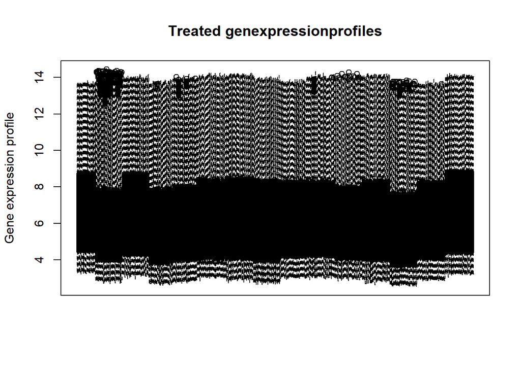

To check, if there is a connection between the different drugs, we coloured the plot concerning the drugs.

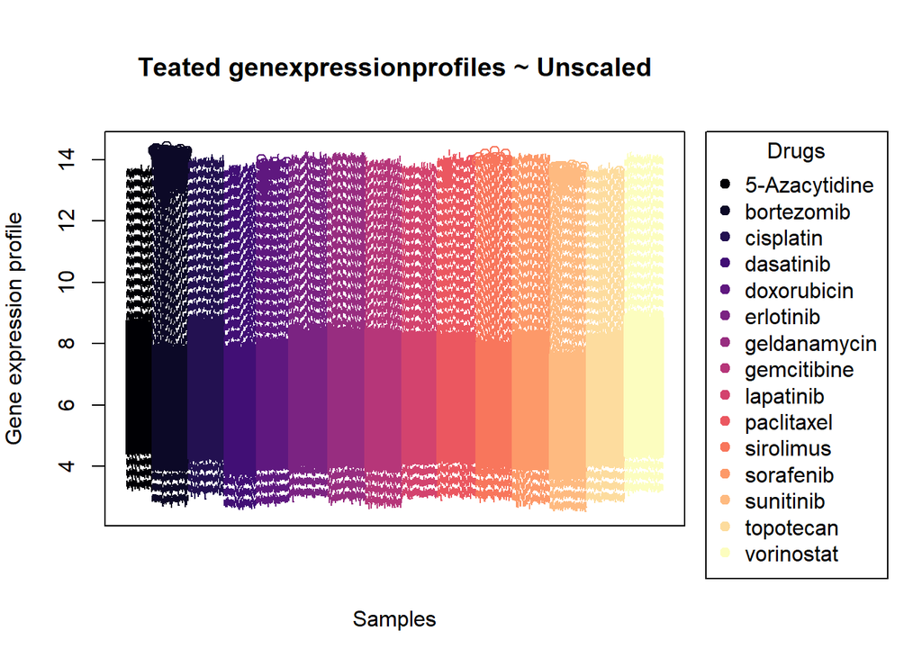

As shown, there is a connection between the different “boxes” and the different drugs. This could be the reason for different batches so we scale the data.

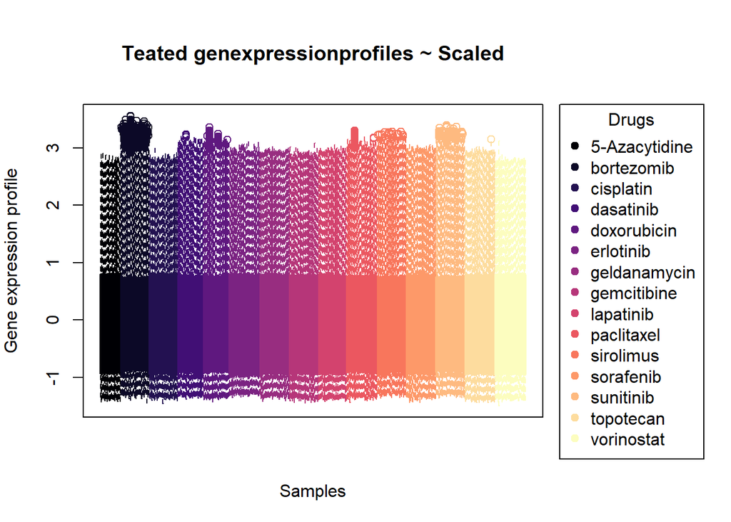

As you can see the scaling is necessary to compensate the batch effect. Scaling is then applied on Untreated as well before further analysis.

## 2.2 Densityplot

As a other method to get in touch with the data, we checked if there is a difference between the treated and untreated genexpression. The abline shows the 3 quantiles ( 25% 50% 75% )

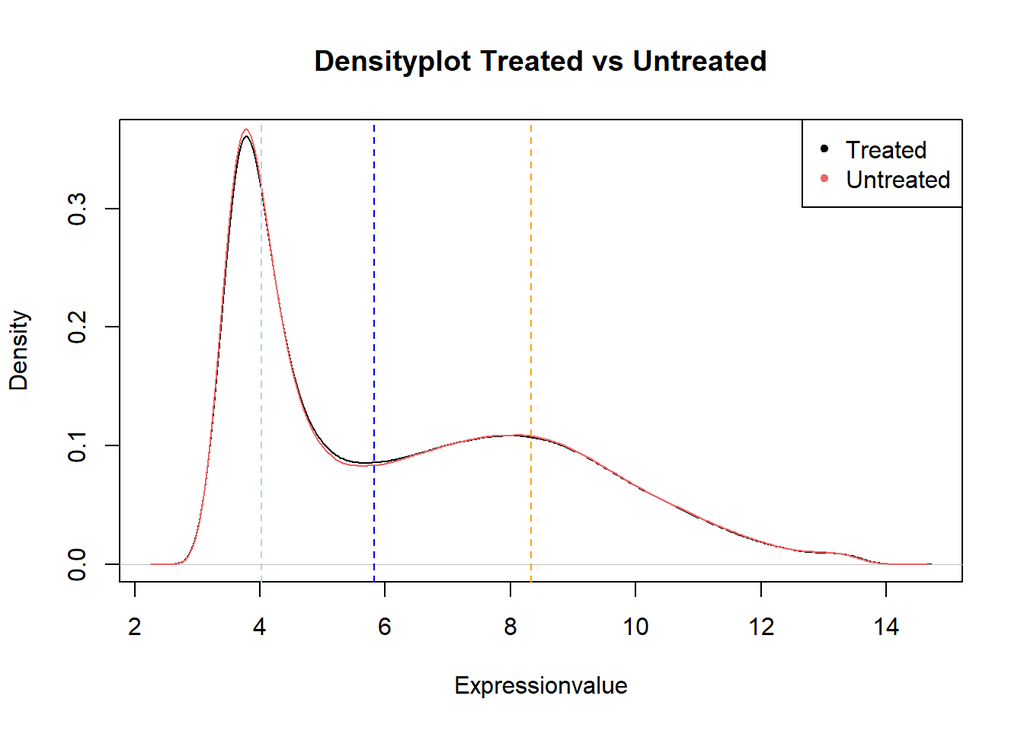

As assumed, the expression patterns don’t differentiate much.

## 2.3 K-means clustering

To look for clusters in the raw data we performed a k-menas clustering and searched for potentially clusters using the most variable (>75% Var), thus informative genes.

Running a loop for the best cluster-amount (searching for an “ellbow”)

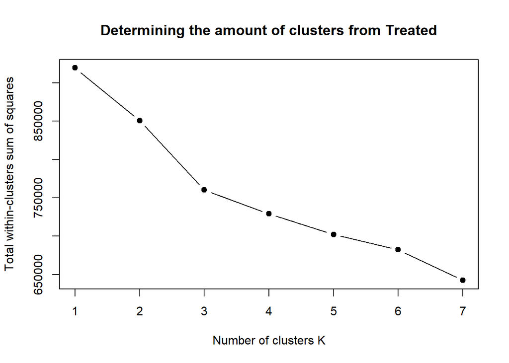

As we wanted an “ellbow”, it is hard to determine the amount of clusters.

## 2.4 PCA

Since the clustering method by performing k means clustering was not successful, we performed a principal component analysis for dimensionality reduction as another method for identifying clusters or patterns while preserving as much information of the original data set as possible.

```r
pca <- prcomp(t(Fold_Change), scale = TRUE)
```

By plotting a scree plot of the variation percentage, we can display how much variation a principal component captures from the original data.

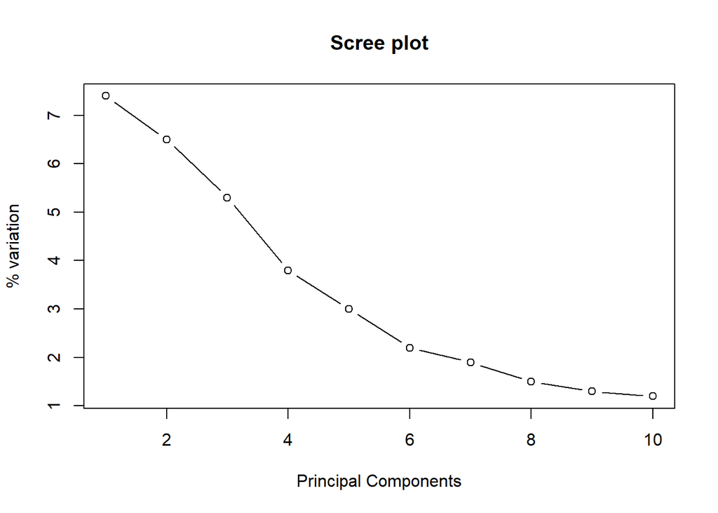

```r
pca.var <- pca$sdev^2  # sdev calculates variation each PC accounts for

pca.var.per <- round(pca.var/sum(pca.var)*100, 1) # since percentages make more sense than normal variation values calculate % of variation

plot(pca.var.per[1:10], main = "Scree plot", type = "b", xlab = "Principal Components", ylab = "% variation")
```

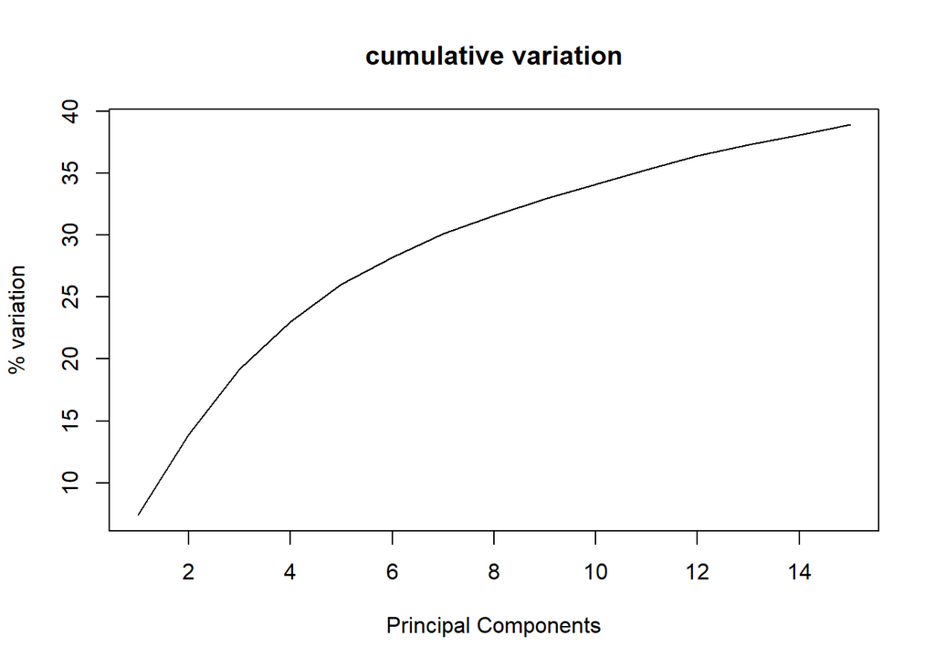

```r
plot(cumsum(pca.var.per[1:15]), main = "cumulative variation", type = "l", xlab = "Principal Components", ylab = "% variation")
```

PCs describe variation and account for the varied influences of the original characteristics. Such influences, or loadings, can be traced back from the PCA to find out which genes contribute most to the single PCS.

```r
## get names of top 10 genes that contribute most to pc1
loading_scores_1 <- pca$rotation[,1]
gene_score <- abs(loading_scores_1) ## sort magnitude
gene_score_ranked <- sort(gene_score, decreasing = TRUE)


top_10_genes <- names(gene_score_ranked[1:10])
top_10_genes # show names of top 10 genes
```

```
##  [1] "DNAJC2"  "NGDN"    "GTPBP4"  "CCDC59"  "DNTTIP2" "AKAP8"   "PAPSS1"
##  [8] "TRMT1"   "BRF2"    "YRDC"
```

To determine clusters of samples based on their similarity, we plotted PC1 and PC2 aswell as a PC2 and PC3 while colouring by tissue type and drug respectively.

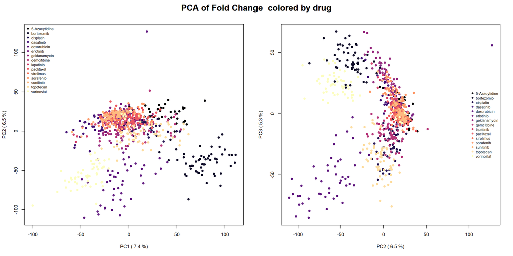

```r
par(mfrow=c(1,2), cex=0.7)
#par(mar=c(4, 6, 3, 3))

## colored by drug
#plot PC1 and PC2
plot(pca$x[,1],
     pca$x[,2],
     col = color_drug,
     pch = 19,
     xlab = paste("PC1 (",pca.var.per[1],"%)"),
     ylab = paste("PC2 (",pca.var.per[2],"%)"))
#create legend
legend("topleft",
       legend = drug,
       col = magma,
       pch = 19,
       xpd = "TRUE",
       bty = "n",
       cex = 0.75
)
#create title
mtext("PCA of Fold Change  colored by drug",
      side = 3,
      line = -2,
      cex = 1.2,
      font = 2,
      outer = TRUE)

#plot PC2 and PC3
plot(pca$x[,2],
     pca$x[,3],
     col = color_drug,
     pch = 19,
     xlab = paste("PC2 (",pca.var.per[2],"%)"),
     ylab = paste("PC3 (",pca.var.per[3],"%)"))
#create legend
legend("right",
       legend = drug,
       col = magma,
       pch = 19,
       xpd = "TRUE",
       bty = "n",
       cex = 0.75,
       inset = c(0, 2)
)
#create title
mtext("PCA of Fold Change  colored by drug",
      side = 3,
      line = -2,
      cex = 1.2,
      font = 2,
      outer = TRUE)
```

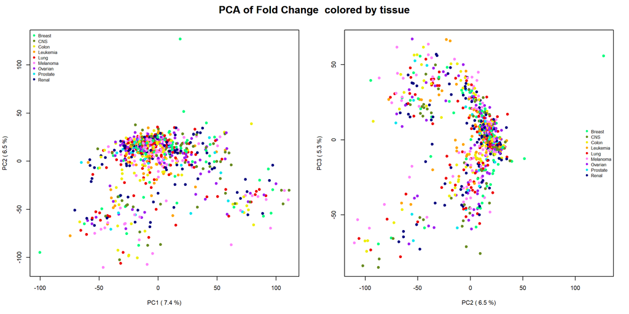

```r
## colored by tissue
#plot PC1 and PC2
par(mfrow=c(1,2), cex=0.7)

plot(pca$x[,1],
     pca$x[,2],
     col = color_tissue,
     pch = 19,
     xlab = paste("PC1 (",pca.var.per[1],"%)"),
     ylab = paste("PC2 (",pca.var.per[2],"%)"))
#create legend
legend("topleft",
       legend = tissue,
       col = viridis,
       pch = 19,
       xpd = "TRUE",
       bty = "n",
       cex = 0.75
)
#create title
mtext("PCA of Fold Change  colored by tissue",
      side = 3,
      line = -2,
      cex = 1.2,
      font = 2,
      outer = TRUE)

#plot PC2 and PC3
plot(pca$x[,2],
     pca$x[,3],
     col = color_tissue,
     pch = 19,
     xlab = paste("PC2 (",pca.var.per[2],"%)"),
     ylab = paste("PC3 (",pca.var.per[3],"%)"))
#create legend
legend("right",
       legend = tissue,
       col = viridis,
       pch = 19,
       xpd = "TRUE",
       bty = "n",
       cex = 0.75,
       inset = c(0, 2)
)
#create title
mtext("PCA of Fold Change  colored by tissue",
      side = 3,
      line = -2,
      cex = 1.2,
      font = 2,
      outer = TRUE)
```

As we can see, in contrast to the k means method, clusters can be determined. Respecting the colour annotation, it is clear to say that the samples cluster according to drug treatment.